# re_airquality

Flueckiger_Rubens; 21-118-385

2025-03-10

# Report Excersice re_airquality

## 1 Load packages

```r
library(tidyr)
library(ggplot2)
library(readr)
library(lubridate)
library(dplyr)
```

## 2 Dataset Information

- Ozone [ppb]
- Solar radiation [J/cm<sup>2</sup>] at frequency band between 4’000 and 7’700 Angstroms
- Average windspeed [mph]
- Maximum daily temperature [°F]

With the provided data, the effect of ozone production at near surface level is analysed. Ozone at near surface levels is created followingly:

$$NO_2 + O_2 <==> NO +
O_3$$

Both reactions take place simultaneously. To enrich the concentration, emitted volatile organic compounds (VOC) can bond with NO and thus limiting the backward reaction.

I hypothesize that a higher wind speed, which should enhance mixing, and solar radiation leads to a higher ozone concentration.

## 3 Analysis

### 3.1 Monthly fluxes

First monthly fluxes are analysed by aggregating daily values over the month.

Windspeed statistics

| Month | Minimum | Maximum | Mean | Variance |
| --- | --- | --- | --- | --- |
| 5 | 5.7 | 20.1 | 11.5 | 12.0 |
| 6 | 8.0 | 20.7 | 12.2 | 14.9 |
| 7 | 4.1 | 14.9 | 8.5 | 9.0 |
| 8 | 2.3 | 15.5 | 8.9 | 11.4 |
| 9 | 2.8 | 16.6 | 10.1 | 12.1 |

Ozone statistics

| Month | Minimum | Maximum | Mean | Variance |
| --- | --- | --- | --- | --- |
| 5 | 1 | 115 | 24.1 | 523.8 |
| 6 | 12 | 71 | 29.4 | 331.5 |
| 7 | 7 | 135 | 59.1 | 1000.8 |
| 8 | 9 | 168 | 60.0 | 1744.5 |
| 9 | 7 | 96 | 31.4 | 582.8 |

Temperature statistics

| Month | Minimum | Maximum | Mean | Variance |
| --- | --- | --- | --- | --- |
| 5 | 57 | 81 | 66.5 | 44.0 |
| 6 | 65 | 90 | 78.2 | 61.4 |
| 7 | 73 | 92 | 83.9 | 19.7 |
| 8 | 72 | 97 | 83.7 | 49.8 |
| 9 | 63 | 93 | 76.9 | 72.3 |

Solar radiation statistics

| Month | Minimum | Maximum | Mean | Variance |
| --- | --- | --- | --- | --- |
| 5 | 8 | 334 | 182.0 | 14072.1 |
| 6 | 37 | 323 | 184.2 | 9159.7 |
| 7 | 7 | 314 | 216.4 | 6478.3 |
| 8 | 24 | 273 | 173.1 | 6215.1 |
| 9 | 14 | 259 | 168.2 | 6464.7 |

Now four plots containing the range and mean value of the observed variables are created.

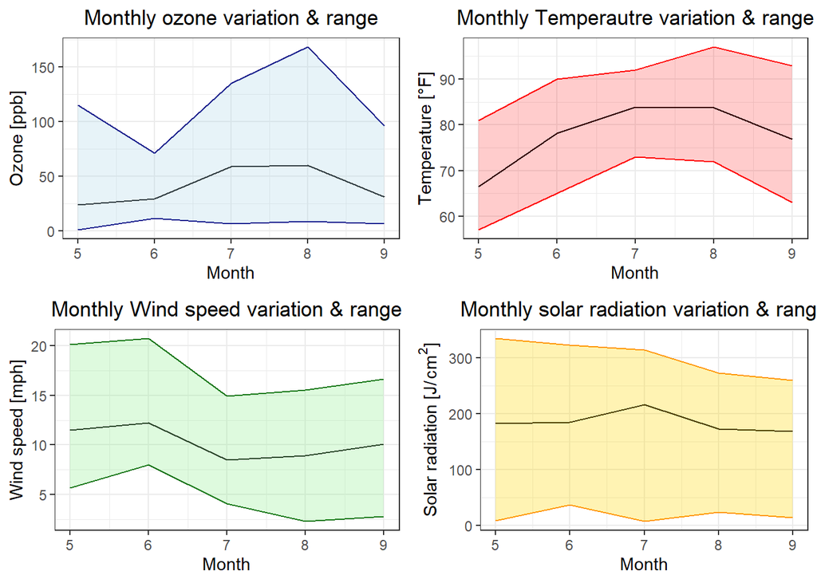

Figure 1: Monthly evolutions

In a next step we take a closer look at inner monthly variations with the help of violin plots.

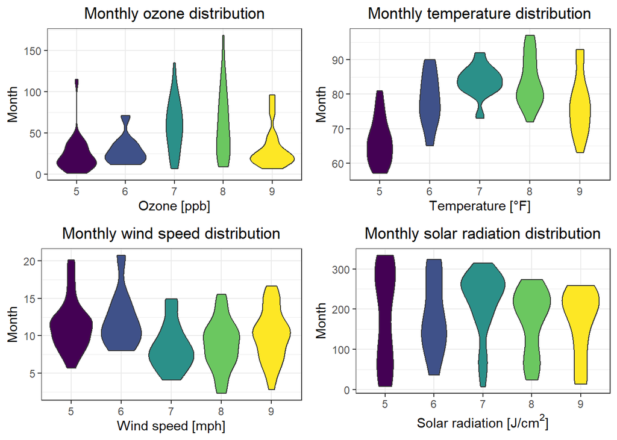

Figure 2: Monthly distributions

One can see that the distributions for low wind speed and ozone, as well as solar radiation and temperature are very similar, which can be explained as solar radiation is the source of temperature.

### 3.2 Scatterplot

**Ozone vs. solar radiation**

Since wind speed seems to have a strong effect for low velocities, we first plot solar radiation against ozone concentration. Then a trend line including the regression coefficient is calculated.

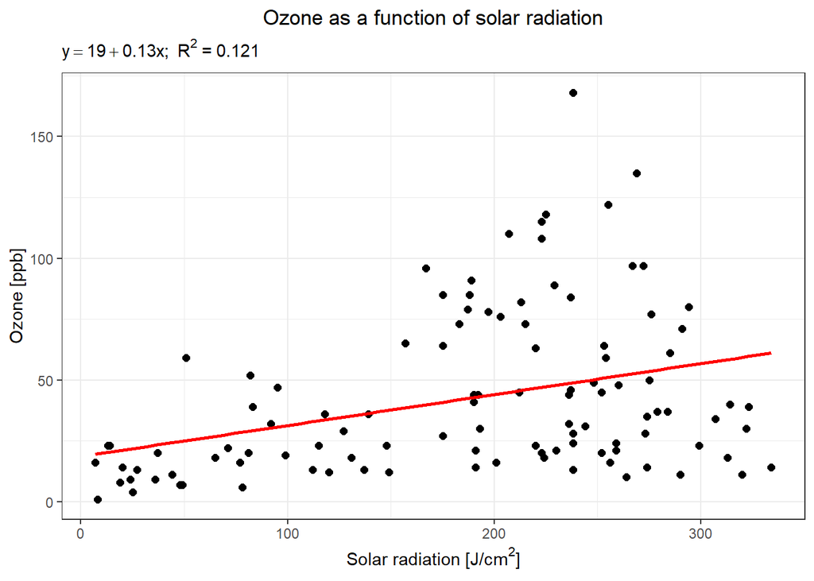

Figure 3: Ozone as a function of solar radiation

**Ozone vs. solar radiation and wind speed**

By plotting the wind speed in colours, we can account for this effect as well.

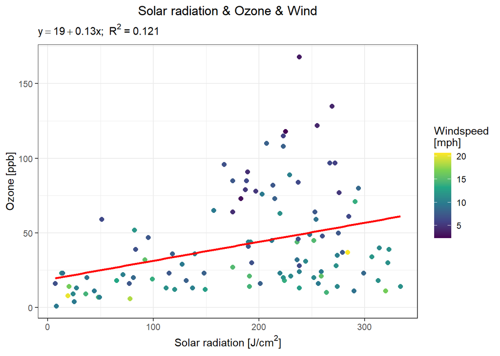

Figure 4: Ozone as a function of solar radiation and windspeed

According to this new plot, we can now see that especially low wind speeds account for especially high ozone concentration.

## 4 Conclusion

According to the analysis done above, my hypothesis is correct regarding higher solar radiation leading to higher ozone concentrations. In contrast to my hypothesis, lower wind speed seams to produce more ozone, which may root from reaction velocity. For higher wind speeds, the reaction of VOC’s with NO may be too low to limit the NO concentration and therefore limiting the enrichment of ozone.